# Introduction to Spatial Regression Methods in Environmental Health

Daniel Beene<sup>1,2</sup>** **Theodros Woldeyohannes<sup>1</sup>

<sup>1</sup> Department of Geography & Environmental Studies, University of New Mexico <sup>2</sup> Community Environmental Health Program, College of Pharmacy, University of New Mexico Health Sciences Center

2024 PEPH Network Meeting NIEHS, Durham NC February 20, 2024

# 1 Background

Geographic Information Systems (GIS) provide versatile tools for uncovering spatial patterns of public health and environmental justice (EJ) issues at multiple scales within the exposome.There are many open-source GIS platforms that allow for cost-effective and equitable integration of GIS tools into data analysis workflows. With open-source GIS, public health researchers can effectively collaborate and easily share reproducible methodologies and findings, helping to foster more inclusive and innovative approaches to cross-cutting health challenges.

In this workshop, you will be introduced to open-source GIS using R, as well as techniques for leveraging GIS tools and spatial data to advance public health research related to the plural environmental health effects of climate change in EJ communities. By participating in this workshop, you will learn the basics of GIS data-structures, loading and visualizing spatial data, and spatial relationships in regression analyses.

## 1.1 Modeling

Modeling, at its most simple, is to use of mathematics and statistical assumptions on sample data to make predictions about the real world. Geospatial modeling adds the assumption that spatial patterns in the data and locations of observations can uncover relationships that may otherwise go missed. Geospatial modeling has applications in diverse topics from the analysis of geomorphic features and physical processes to logistics and supply chains. One domain of study that can be enhanced through geospatial modeling is public health and epidemology, in which associations between health outcomes and predictor variables can be viewed as inherently spatial processes. To understand the nuance of geospatial modeling as it relates to public health, we must first go over the distinction between global and local models.

### 1.1.1 Global Models

Modeling approaches that don’t explicitly account for spatial relationships, but rather weight every observation the same regardless of its spatial location are referred to here as *global*. On the other hand, *local* models also consider spatial relationships between observations as an important explanatory variable. A global model considers the relationships between all dependent and independent variables across the entire study extent, with the assumption that observed relationships hold true at all locations within the extent. The implications of these assumptions are that data from different locations within a model can be used with equal weighting, allowing for the estimation of a single parameter for each relationship being modeled. Geographers have pointed out for some time that the assumptions of global models have flaws, especially when examining complex relationships. In certain cases, spatial relationships act as lurking variables that drastically change the direction of $\beta$ coefficients - this is an example of [Simpson’s paradox](https://cs.brown.edu/courses/cs100/lectures/readings/Kgel_Simpsonsparadoxversusecologicalfallacy-TheTFRFLPpuzzle.pdf) in spatial relationships. Sachdeva and Fotheringham (2023) explore this in detail [here](https://josis.org/index.php/josis/article/view/212/172).

### 1.1.2 Local Models

In the context of spatial statistics, a local model considers the relationships between dependent and independent variables (or a sub-set of these variables) across a localized area of the study extent. We refer to these localized areas as ‘neighborhoods’. Local models assume that observed relationships only hold within the neighborhood, and may vary across neighborhoods. This allows for local models to potentially model processes that vary over space with greater accuracy. This is valuable in the realm of public health, in which associations between environmental exposure, human behavior, and health outcomes are complex and often present as non-linear, spatially heterogeneous relationships.

### 1.1.3 Spatial Autocorrelation

Spatial Autocorrelation is when data from locations near one another in space are more likely to be similar (i.e. are more correlated) than data from locations remote from one another. Spatial autocorrelation can be thought of as a double-edged sword. From a geographic perspective, we expect that raw data will show spatial autocorrelation, and use this to our advantage. For example, there is a notion in geography known as [Tobler’s First Law of Geography](https://gisgeography.com/tobler-first-law-of-geography/), in which it is assumed that objects in space closer to each other are more likely to be related than objects that are farther apart. When examining processes that vary over space, we assume that data representing these processes will be non-randomly distributed (i.e. show spatial autocorrelation), and that in assessing these distributions through spatial statistics, we can infer otherwise hidden properties of the process.

In this workshop, we will measure the spatial autocorrelation of model residuals. If residuals are spatially autocorrelated then we can conclude that the given model is poorly specified by not attending to all spatial relationships between model terms. *Local models do not necessarily account for all spatial autocorrelation in model residuals.*

#### 1.1.3.1 Geographically Weighted Regression (GWR)

[Geographically weighted regression](https://doi.org/10.1111/1467-9884.00145) (GWR) is a spatial regression technique that evaluates a local model of the variable or process you are trying to understand or predict by fitting a regression equation to every feature within a predetermined neighborhood in the dataset. While GWR is a local model, it does not assess the spatial scale at which processes may vary. In other words it assumes variance across an extent, but that all variances exist at the same spatial scale for every model term.

#### 1.1.3.2 Multiscale Geographically Weighted Regression (MGWR)

[Multiscale geographically weighted regression](https://doi.org/10.1080/24694452.2017.1352480) (MGWR) builds upon the GWR technique by optimizing neighborhood sizes for each explanatory variable. This allows for the MGWR framework to examine both spatial variability and scalar effects simultaneously in local modeling.

#### 1.1.3.3 Other Modeling Approaches

[Spatial autoregressive models](https://s4.ad.brown.edu/resources/tutorial/modul2/geoda3final.pdf) (SAR) are one of the most common approaches for handling spatial autocorrelation in datasets. Generally, they utilize one of two techniques: 1) a *spatial error model* computes an error coefficient ($\lambda$) to test whether spatial error between terms is correlated, and 2) a *spatial lag model* introduces a spatial lag term $\rho$ to test if th dependent variable is affected by multiple independent observations at different locations. These methods are most commonly conducted in the open source GIS package, [GeoDa](https://geodacenter.github.io/). Various other local spatial models include Bayesian Spatially Varying Coefficients Models, Spatial Filtering methods, and Spatially Clustered Coefficient models. Additionally, other kinds of modeling approaches, such as machine learning based models, can be used to assess spatial relationships in data. This workshop will focus on the MGWR framework, given its computational efficiency, robust support in R, and widespread use.

# 2 Example: Low Birthweight Rates

In this workshop, you will examine how rates of low-weight births (LWB) in Colorado relate to environmental pollution and socioeconomic covariates. Our main objective is to demonstrate how spatial relationships may be lurking variables in regression models.

Using this data, we will model the relationship between LWB and environmental pollution, corrected for social vulnerability variables using:

1. An ordinary least squares (linear) model,
2. A geographically weighted regression, and, optionally
3. A multiscale geographically weighted regression.

For each model we will examine model diagnostics, including:

1. Overall model strength and predictive capability,
2. Distribution (normality) of model residuals, and
3. Spatial autocorrelation of model residuals.

## 2.1 Getting Started

Like most scripting languages, base R offers an array of basic commands for data manipulation and analysis. However, if you want to do anything more technical or esoteric, you have to download and install specialized packages.

$\textbf{A note on R:}$ R is an extensive coding environment. It would be impossible to explain every command in this workshop. The intent of this workshop is to introduce you to performing spatial data-analysis in R, and give you to the background to learn and apply these techniques in your own research.

The open source community has designed [“cheat sheets”](https://posit.co/resources/cheatsheets/) for different R topics. Please refer to the [Base R cheat sheet](https://rstudio.github.io/cheatsheets/base-r.pdf) for descriptions of common commands and operators. In R Studio, you can navigate to *Help>Cheatsheets* to access all of them. There is also a wealth of community information online. A quick Google search can point toward solutions for many problems. Below we have provided basic information on key ideas and commands for this workshop:

- *variable* - In R we define data-objects, such as a spreadsheet of SVI data per census tract, as a variable. Variables allow us to easily reference complex data objects in code functions.
- *$ (extractor operator)* - The $ is the extractor operator. It is used to reference specific variables in a data table or object.
- *<- (assignment operator)* - The <- is the assignment operator. This can be thought of as an ‘=’ (equals). We use the assignment operator to define variables.
- *%>% (pipe operator)* - The %>% is the pipe operator. This is a way to chain operations together (i.e. ‘pipe’ information). It takes the output from the left of the pipe and passes it to an expression on the right. For example, we can use the pipe to take the data-object represented by a variable, and input (‘pipe’) this into a function. Pipes are not a part of base R, which is why we call in the *dplyr* library.
- *Data Frame* - Tables of data in R are referred to as ‘data frames’. This is basically a data-object that acts like a spreadsheet, in which columns are variables/fields and rows are observations.

### 2.1.1 Install packages

Both code chunks below load the necessary packages to complete the workshop. If you have installed all of the required packages, skip the first chunk and run the second one by clicking on the green arrow in the top right corner of the chunk. If you need to install any libraries, un-comment any or all of the lines below by removing the #. (*Hint: you can comment or un-comment lines by selecting them and pressing Ctrl+Shift+C.)

```r
## Installing libraries
## If you don't have any of the required packages installed, un-comment and run the necessary lines
# install.packages("GWmodel")
# install.packages("ggplot2")
# install.packages("GGally")
# install.packages("gridExtra")
# install.packages("tmap")
# install.packages("dplyr")
# install.packages("sf")
# install.packages("stringr")
# install.packages("tidyverse")
# install.packages("Hmisc")
# install.packages('car')
# install.packages('Rtools')
# install.packages('nortest')
# install.packages('spdep')
```

### 2.1.2 Load Libraries into R Environment (STEP 0)

Even if you’ve downloaded and installed the necessary libraries, they haven’t been called directly into the current R environment. This step is required for running the functions throughout the workshop.

```r
# Import libraries
library(GWmodel)
library(ggplot2)
library(GGally)
library(gridExtra)
library(tmap)
library(dplyr)
library(sf)
library(stringr)
library(tidyverse)
library(Hmisc)
library(car)
library(nortest)
library(spdep)

source("plotting_functions.R")
```

## 2.2 Data

This workshop uses the datasets below, all of which contain data aggregated to census tracts in Colorado:

$\textbf{Outcome:}$ 2018 rate of low weight births (LWB) provided in the Colorado Department of Public Health and Environment (CDPHE) [Open Data portal](https://data-cdphe.opendata.arcgis.com/datasets/cdphe-composite-selected-health-outcome-dataset-census-tract/explore).

$\textbf{Main Exposure:}$ 10-year average (2008 - 2018) of total releases in pounds from [Toxic Release Inventory](https://www.epa.gov/toxics-release-inventory-tri-program/tri-basic-data-files-calendar-years-1987-present) (TRI) facilities within 50 kilometers of [population-weighted census tract centroids](https://www.census.gov/geographies/reference-files/time-series/geo/centers-population.2010.html#list-tab-1319302393) in Colorado.

$\textbf{Covariates:}$ Estimated proportions of census tract-level social vulnerability from the [2018 ATSDR-CDC Social Vulnerability Index](https://www.atsdr.cdc.gov/placeandhealth/svi/documentation/pdf/SVI2018Documentation_01192022_1.pdf).

Raw data is imported in the form of spreadsheets, in which observations have location identifiers. We then put this data into a GIS environment and spatialize it by joining the data to spatial objects. For this workshop we will use vector data. Vector data can simply be thought of as polygons (shapes) with location information. In other words, areas projected onto the surface of the Earth. For this workshop we will use vector data in *shapefile* format. In the case of this workshop, these shapes represent the census tracts of the state of Colorado. By joining the raw data to census tracts, we can use spatial statistics to analyze the spatial relationships within the data.

Shapefiles are a data format for storing geometry and attribute information of a spatial dataset. Notice that we only read in one file with a .shp extension, but that the file directory *./Tracts* contains 7 items with the same name but different extensions. All of these files are necessary for GIS software to read and display a .shp.

*tl_2010_08_tract10.shp* is a product of the U.S. Census Bureau called the [TIGER/Line Shapefiles](https://www.census.gov/geographies/mapping-files/time-series/geo/tiger-line-file.html) (TIGER stands for Topologically Integrated Geographic Encoding and Referencing system.)

### 2.2.1 Import Shapefile (STEP 1)

We will use the [sf](https://cran.r-project.org/web/packages/sf/index.html), or Simple Features, library to import the shapefile of census tracts and name it `dat_tracts`. We then draw a very basic map just to ensure that it is rendering correctly. Run the code chunk below by clicking on the green arrow in the top right of the chunk.

```r
# Import shapefile
dat_tracts <- st_read(dsn = "./Tracts/tl_2010_08_tract10.shp")
```

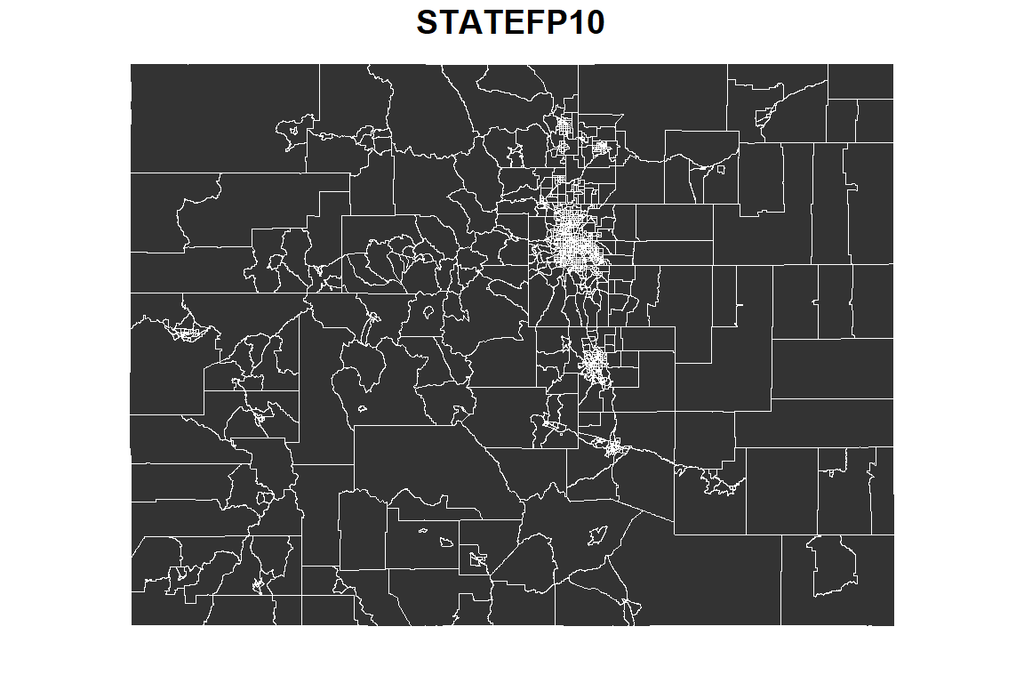

```r
# Plot shapefile with base R - this is just to check that it renders correctly
par(mar=c(0,0,0,0))
plot(dat_tracts, col="#333333", lwd=0.25, border=0, max.plot = 1)
```

### 2.2.2 Import Exposure Data (STEP 2)

Next, we will use base R to read in the CSV of exposure data and name it `dat_tri`. The first thing we need to do after importing the CSV data table is ensure that the census tract ID (GEOID) is the correct length. Some states have a GEOID that begins with 0, Colorado being one of them (08). The problem is that CSV files will often remove the leading 0 in numbers. Since all GEOIDs are standardized by the US Census to a length of 11 characters $^1$, here we make sure that every GEOID in the table is 11 characters long by padding them with a 0 on the left side.

```r
dat_tri <- read.csv('./Exposure/avgReleases_tract_popCenter_50km_CO_2008-2018.csv')
# Pad GEOID to 11 characters
dat_tri$GEOID10 <- str_pad(dat_tri$GEOID10, width = 11, side = "left", pad = 0)

# unique(nchar(dat_tri$GEOID10)) # Un-comment this line if you want to check if padding worked
```

### 2.2.3 Import Confounders (STEP 3)

This data table contains 2018 SVI data aggregated to census tracts. We first read in the data table and define it as a variable `svi`, and format to pad GEOIDs (called ‘FIPS’ in the SVI dataset)$^1$ as done in Step 2. Next, we pipe the `svi` variable into a filtering function ‘filter()’, to filter out data that is not located with Colorado census tracts, and define this filtered data as a new variable `svi_sub`. Next, we convert missing values (-999) to *NA*; this will make it easier to exclude missing values from statistical analysis later on. Lastly, we pipe the `svi_sub` variable into the *select()* function to select only fields that start with “SPL_THEME”, and overwrite the `svi_sub` variable with this selection.

There are four SPL_THEME variables in the 2018 SVI. They are the sum of variables included in four themes generally related to social vulnerability:

1. $\textbf{Theme 1}$: Socioeconomic status
   - Below poverty
   - Unemployed
   - Income
   - No high school diploma
2. $\textbf{Theme 2}$: Household characteristics
   - Aged 65 or older
   - Aged 17 or younger
   - Civilian with a disability
   - Single-parent households
3. $\textbf{Theme 3}$: Minority status and language
   - Minority
   - Aged 5 or older who speaks English “less than well”
4. $\textbf{Theme 4}$: Housing type and transportation
   - Multi-unit structures
   - Mobile homes
   - Crowding
   - No vehicle
   - Group quarters

$^1$ *You will often see FIPS and GEOID used interchangeably. This is technically incorrect. Per the [US Census Bureau](https://www.census.gov/library/reference/code-lists/ansi.html), Federal Information Processing Series (FIPS) codes are 5-digit county subdivisions. A GEOID is a concatenation of codes for state, county, and census tract, totaling 11 characters.*

```r
svi <- read.csv('./Confounders/SVI_2018_US.csv') # SVI data for all census tracts in US
svi$FIPS <- str_pad(svi$FIPS, width = 11, side = "left", pad = 0) # Pad GEOIDs so that they are all 11 characters long
# unique(nchar(svi$FIPS))

svi_sub <- svi %>%
  filter(ST_ABBR %in% c("CO")) # Subset SVI to only include tracts in Colorado

svi_sub[svi_sub == -999] <- NA # Missing values are coded as -999, here we replace -999 with NA

# Keep percentage, percentile, theme ranking, flag variables, and total population
svi_sub <- svi_sub %>%
  dplyr::select(FIPS, starts_with(c("SPL_THEME")))

# unique(nchar(svi_sub$FIPS))
```

All GEOIDs in the SVI dataset are 11 characters long.

### 2.2.4 Import Outcome (STEP 4)

This data table contains health outcome data aggregated to census tracts. We first read in the data table and define it as a variable `outcome`. Next, we select the fields we need (GEOID and any variables related to LWB) and define this selection as a new variable `lwb`. Lastly, we again format to pad the GEOIDs as done in steps 2 and 3.

```r
outcome <- read.csv('./Outcome/CDPHE_Composite_Selected_Health_Outcome_Dataset_(Census_Tract).csv')
lwb <- outcome[, c(2, 26:32)] # Subset to only include low birthweight variables and GEOID

lwb$TRACT_FIPS <- str_pad(lwb$TRACT_FIPS, width = 11, side = "left", pad = 0) # Pad GEOIDs so that they are all 11 characters long

# unique(nchar(lwb$TRACT_FIPS))
```

All GEOIDs in the LWB dataset are 11 characters long.

### 2.2.5 Combine Data Tables (STEP 5)

Join the formatted data tables of TRI releases (exposure), SVI confounders, and LWB (outcome) to the census tract shapefile, creating a combined spatial dataset. This combined dataset will then be ready to be fed into statistical models. However, since attribute joins can’t be performed on a large SpatialPolygonsDataframe directly, we first convert `dat_tracts` into a normal data frame, allowing us to perform join operations.

We define the converted shapefile as new variable `dat_full`, then we pipe the census tracts into a series of join functions *right_join()*, joining the TRI, SVI, and LWB data tables to create a combined table. We overwrite `dat_full` with the new combined data table. Next, we create a subset of the dataset and define as a new variable `global_dat` for use in the global linear regression model.

*Optional: after you finish the workshop, come back to this step and follow instructions in the code comments to investigate how removing potential outliers affects results*.

Next, we convert `dat_full` back into spatial format for use in spatial statistical models. Lastly, we return a summary of `dat_full` to make sure data was joined properly (reference the finished HTML document to make sure your summary looks correct).

```r
# Combine data tables

# Join data using the dplyr library - this doesn't work on SpatialPolygonDataFrame data types, so convert first
dat_full <- st_as_sf(dat_tracts)

dat_full <- dat_full %>%
  right_join(dat_tri, by = c("GEOID10" = "GEOID10")) %>% # Exposure
  right_join(lwb, by = c("GEOID10" = "TRACT_FIPS")) %>% # Outcome
  right_join(svi_sub, by = c("GEOID10" = "FIPS")) # Confounders

# Create a subset for global models
global_dat <- dat_full %>%
  # select(GEOID10, avgReleasesLb_10yr, LWB_ADJRATE, E_TOTPOP, starts_with("EP_")) # Keep total population estimate (E_TOTPOT) and land area (ALAND10) for later reference
  select(GEOID10, avgReleasesLb_10yr, LWB_ADJRATE, starts_with("SPL_"))
global_dat <-
  data.frame(global_dat[, 1:8]
             )
# %>% # To only keep certain observations, uncomment this line and move the pipe (%>%) up to the line above
#   # Only retain observations we're analyzing
#   slice(
#     -659
#   )

dat_full <- as(na.omit(dat_full), "Spatial") # Convert dat_full back to spatial - we will use this for the spatial models

summary(dat_full)
```

```
Object of class SpatialPolygonsDataFrame
Coordinates:
         min        max
x -109.06026 -102.04158
y   36.99242   41.00344
Is projected: FALSE
proj4string : [+proj=longlat +datum=NAD83 +no_defs]
Data attributes:
  STATEFP10          COUNTYFP10         TRACTCE10           GEOID10
 Length:1201        Length:1201        Length:1201        Length:1201
 Class :character   Class :character   Class :character   Class :character
 Mode  :character   Mode  :character   Mode  :character   Mode  :character



    NAME10           NAMELSAD10          MTFCC10           FUNCSTAT10
 Length:1201        Length:1201        Length:1201        Length:1201
 Class :character   Class :character   Class :character   Class :character
 Mode  :character   Mode  :character   Mode  :character   Mode  :character



    ALAND10             AWATER10         INTPTLAT10         INTPTLON10
 Min.   :1.556e+05   Min.   :       0   Length:1201        Length:1201
 1st Qu.:1.932e+06   1st Qu.:       0   Class :character   Class :character
 Median :3.449e+06   Median :    5172   Mode  :character   Mode  :character
 Mean   :1.879e+08   Mean   :  858774
 3rd Qu.:1.919e+07   3rd Qu.:  157285
 Max.   :9.748e+09   Max.   :73093771
 avgReleasesLb_10yr  LWB_ADJRATE       LWB_L95CI        LWB_U95CI
 Min.   :     0     Min.   : 0.000   Min.   : 0.000   Min.   : 0.00
 1st Qu.:  4893     1st Qu.: 5.800   1st Qu.: 2.710   1st Qu.: 8.89
 Median :  5013     Median : 7.190   Median : 3.910   Median :10.73
 Mean   : 25259     Mean   : 7.421   Mean   : 4.057   Mean   :11.31
 3rd Qu.: 13070     3rd Qu.: 8.840   3rd Qu.: 5.240   3rd Qu.:13.14
 Max.   :613759     Max.   :25.000   Max.   :12.680   Max.   :45.74
 LWB_STATEADJRATE   LWB_SL95CI     LWB_SU95CI   LWB_DISPLAY
 Min.   :7.43     Min.   :7.34   Min.   :7.52   Length:1201
 1st Qu.:7.43     1st Qu.:7.34   1st Qu.:7.52   Class :character
 Median :7.43     Median :7.34   Median :7.52   Mode  :character
 Mean   :7.43     Mean   :7.34   Mean   :7.52
 3rd Qu.:7.43     3rd Qu.:7.34   3rd Qu.:7.52
 Max.   :7.43     Max.   :7.34   Max.   :7.52
   SPL_THEME1       SPL_THEME2       SPL_THEME3       SPL_THEME4
 Min.   :0.0775   Min.   :0.0178   Min.   :0.0400   Min.   :0.000
 1st Qu.:0.8266   1st Qu.:1.3987   1st Qu.:0.5798   1st Qu.:1.306
 Median :1.3852   Median :1.7535   Median :0.9012   Median :2.061
 Mean   :1.5476   Mean   :1.7498   Mean   :0.9300   Mean   :2.028
 3rd Qu.:2.2083   3rd Qu.:2.1415   3rd Qu.:1.2640   3rd Qu.:2.762
 Max.   :3.9689   Max.   :3.4910   Max.   :1.8783   Max.   :4.472
   SPL_THEMES
 Min.   : 1.572
 1st Qu.: 4.523
 Median : 5.940
 Mean   : 6.255
 3rd Qu.: 7.949
 Max.   :12.121
```

#### 2.2.5.1 Correlation Matrix

Before we pump the data into models, we’ll start by exploring pairwise relationships between them to assess whether there are any nonlinear relationships.

The code chunk below creates a correlation matrix plot of the variables from our combined dataset. We first define a new variable `vars` as a list of the variable names. Next, we create a subset data table by selecting from `global_dat` the list of variables contained in `vars`. Lastly, we pass this data to a plotting function *ggpairs()* and define the output plot as variable `p_cor`, and print `p_cor` to display it below the code chunk.

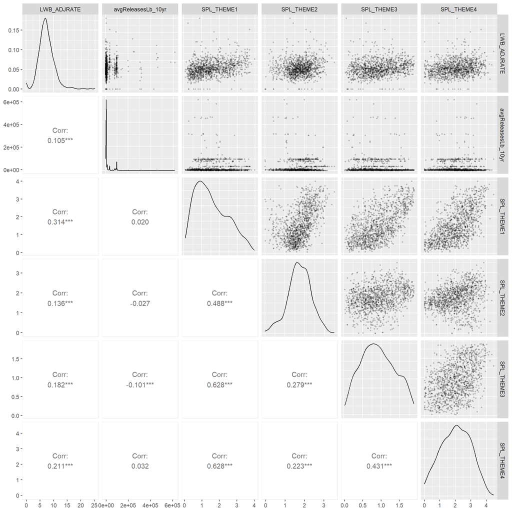

```r
# # Optional: Log-transform exposure variable
# global_dat <- global_dat %>%
#   mutate(
#     avgReleasesLb_10yr = log10(avgReleasesLb_10yr + 0.00001)
#   )

# Plot correlation matrix of variables from the global model
vars <- c(
  "avgReleasesLb_10yr", "SPL_THEME1", "SPL_THEME2", "SPL_THEME3", "SPL_THEME4"
)

# Create a subset of 'global_dat' with selected variables
global_dat_sub <- global_dat[, c("LWB_ADJRATE", vars)]

# Plot the correlation matrix using ggpairs
p_cor <- ggpairs(
  global_dat_sub,
  upper = list(continuous = wrap("points", alpha = 0.2, size = 0.5)),
  lower = list(continuous = "cor")
)

print(p_cor)
```

In the correlation matrix above, we don’t see any strongly nonlinear relationships between explanatory variables, but we do see that the exposure variable, `avgReleasesLb_10yr` is *very* right-skewed, meaning that the majority of observations are at or close to 0. However, we won’t perform any transformations to the variables to make interpretation and comparison of the three models more straightforward.

*If you want to try log-transforming the exposure variable, un-comment the top 5 lines in the chunk above and run the rest of the markdown file as normal. Be sure that you account for this in your interpretation.*

## 2.3 Global Model

### 2.3.1 Fit Full Linear Model (STEP 6)

In this code chunk we run an ordinary least squares linear regression, with LWB rates as the dependent variable, TRI releases as the exposure, and SVI variables as confounders. We first pass `global_dat` through the linear model function, *lm()*, and define the output of the model as `lm_full`. Then we return a summary of `lm_full`.

```r
# Fit global model
lm_full <- lm(LWB_ADJRATE ~ avgReleasesLb_10yr + SPL_THEME1 + SPL_THEME2 + SPL_THEME3 + SPL_THEME4
              , data = global_dat)

summary(lm_full)
```

```
Call:
lm(formula = LWB_ADJRATE ~ avgReleasesLb_10yr + SPL_THEME1 +
    SPL_THEME2 + SPL_THEME3 + SPL_THEME4, data = global_dat)

Residuals:
    Min      1Q  Median      3Q     Max
-8.7475 -1.4913 -0.1646  1.2078 18.2726

Coefficients:
                     Estimate Std. Error t value Pr(>|t|)
(Intercept)         6.044e+00  2.819e-01  21.437  < 2e-16 ***
avgReleasesLb_10yr  5.182e-06  1.219e-06   4.251 2.29e-05 ***
SPL_THEME1          9.316e-01  1.363e-01   6.836 1.29e-11 ***
SPL_THEME2         -2.064e-01  1.473e-01  -1.401    0.161
SPL_THEME3          7.404e-02  2.114e-01   0.350    0.726
SPL_THEME4          4.765e-02  9.765e-02   0.488    0.626
---
Signif. codes:  0 '***' 0.001 '**' 0.01 '*' 0.05 '.' 0.1 ' ' 1

Residual standard error: 2.489 on 1195 degrees of freedom
  (69 observations deleted due to missingness)
Multiple R-squared:  0.1137,    Adjusted R-squared:   0.11
F-statistic: 30.65 on 5 and 1195 DF,  p-value: < 2.2e-16
```

### 2.3.2 Global Model Interpretation (STEP 7)

#### 2.3.2.1 Model Diagnostics

Next, we will conduct a few diagnostics of the global model. There are many more possible diagnostics that aren’t presented here. For example, examining a) the leverage of individual observations and b) the individual contribution of variables with added-variable plots.

##### 2.3.2.1.1 Normality of Residuals

First, we plot the distribution of model residuals against a normal probabilistic distribution (a quantile-quantile, or QQ, plot) to see if the residuals demonstrate any unexpected patterns, and to identify any data points that exert increased influence on overall model fit.

In this chunk, we pass the residuals from `lm_full` into the *car* library function, *qqPlot*.

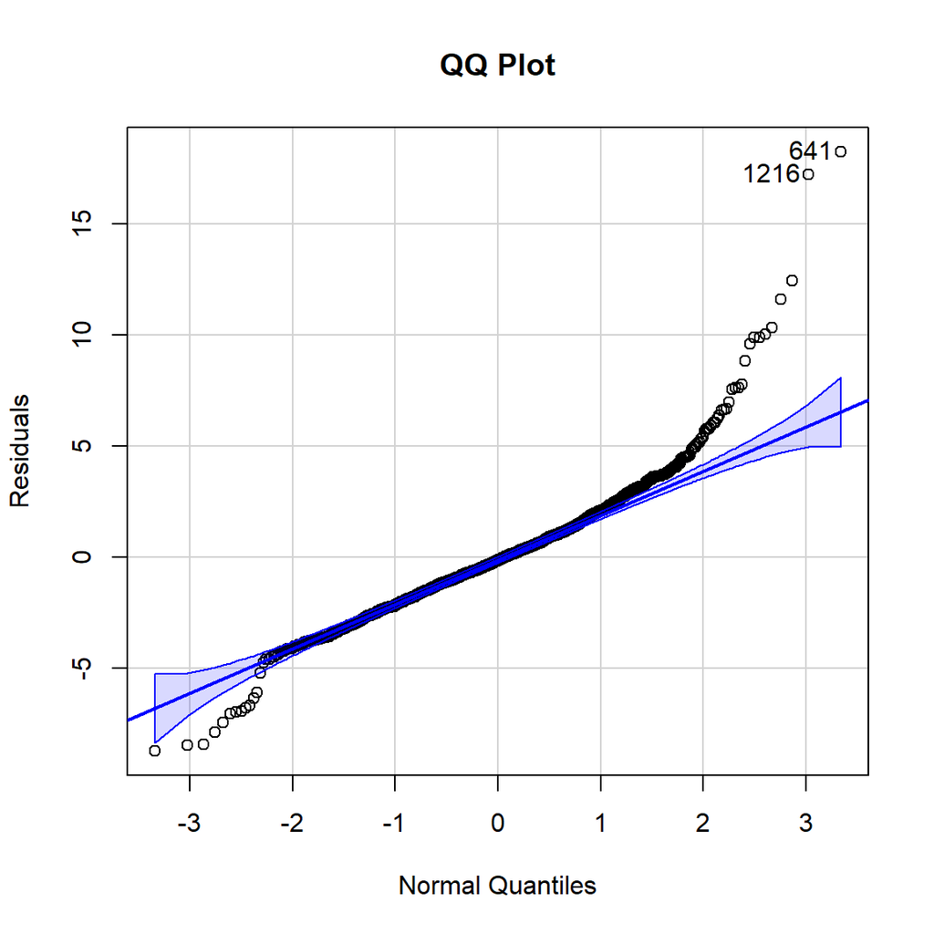

```r
# QQ Plot
qq_lm_full <- qqPlot(residuals(lm_full), main = "QQ Plot", xlab = "Normal Quantiles", ylab = "Residuals")
```

```r
print(qq_lm_full)
```

```
 641 1216
 616 1169
```

The QQ plot does suggest that the model is somewhat poorly specified because a large proportion of residuals vs. normal values fall outside the standard error range at both the lower and upper bounds, suggesting some [heteroskedasticity](https://statisticsbyjim.com/regression/heteroscedasticity-regression/) or [kurtosis](https://statisticsbyjim.com/basics/kurtosis/) of model residuals.

If we were to proceed only with a linear model, we might consider taking measures including transforming data or excluding individual observations to account for this nonlinear structure.

##### 2.3.2.1.2 Spatial Autocorrelation of Residuals

Run the code chunk below to test for spatial autocorrelation in the residuals of our linear model.

We do this by first selecting the residuals from the model output and defining the residuals as new variable `lm_resid_col`. Next, using row names as a key, we join the column of residuals to `dat_full`.

The function below performs a *Anselin Local Moran’s* $I$, which differs from the global *Moran’s* $I$ test for spatial autocorrelation by computing the $I$ statistic for every location, $i$, as well as the local variance and $z$ value, as opposed to a single $I$ for the whole datset. Like the global approach, the local test tells us the degree of similarity between every observation and its neighbors, however it allows us to identify more localized clusters of (dis)similarity.

Once the data are joined we prepare for the test by constructing a list of neighbors for every observation, `nb`. Next we compute spatial weights `lw` for every neighbor to pass into the *Moran’s* $I$ test by summing all residuals in each neighborhood divided by the number of observations per neighborhood. Then we pass these parameters, along with `dat_full$residuals`, to the `moran.mc` function to test for spatial autocorrelation over 999 permutations. Each permutation randomly rearranges the neighborhood values around each observation to account for the inevitable random clustering of values.

```r
# Spatial autocorrelation of global linear model residuals
lm_resid_col <- lm_full$residuals # Make data table of residuals from lm_red_AIC
dat_full$residuals <- lm_resid_col[as.character(rownames(dat_full@data))] # Append residuals to dat_full by row name

nb <- poly2nb(dat_full, queen = TRUE) # Define neighbors for each polygon
lw <- nb2listw(nb, style = "U", zero.policy = TRUE) # Assign weights to neighbors
moran_lm <- moran.mc(dat_full$residuals
                    , lw
                    , nsim = 999
                    , alternative = "two.sided")
print(rbind("Moran's I statistic: " ,moran_lm$statistic))
```

```
     statistic
[1,] "Moran's I statistic: "
[2,] "0.107895195158953"
```

```r
print(rbind("P-value of Moran's I statistic: ", moran_lm$p.value))
```

```
     [,1]
[1,] "P-value of Moran's I statistic: "
[2,] "0"
```

## 2.4 Local Models

### 2.4.1 Calculate Distance Matrix (STEP 8)

A key element of geographically weighted regressions is the spatial distance between observations. This is often measured as a straight line (Euclidean distance), but there are other approaches. For example, geodesic distance considers the curvature of the earth, which is appropriate when observations are very far apart

Run the below code chunk to calculate a distance matrix, `DM`, between all observations in `dat_full`. A distance matrix is a matrix in which elements correspond to estimates of a pairwise distance between the sequences in a set. This can be simply though of as a measure of the distances between the locations of all of our observations in our data table.

```r
# Calculate distance matrix
DM <- gw.dist(dp.locat = coordinates(dat_full))
```

### 2.4.2 Compute Bandwidths (STEP 9)

Bandwidth, or neighborhood size, is the most influential parameter in GWR because it can significantly change parameter estimates. Simply put, larger bandwidths have smaller parameter weights thus increasing variation, and shorter bandwidths have larger weights to reduce local variation of parameters. Here, we use an automated cross-validation (CV) approach to optimize weights for each model term.

```
Adaptive bandwidth: 749 CV score: 7413.226
Adaptive bandwidth: 471 CV score: 7386.829
Adaptive bandwidth: 297 CV score: 7379.676
Adaptive bandwidth: 192 CV score: 7343.724
Adaptive bandwidth: 124 CV score: 7318.098
Adaptive bandwidth: 85 CV score: 7308.152
Adaptive bandwidth: 58 CV score: 7320.871
Adaptive bandwidth: 99 CV score: 7319.242
Adaptive bandwidth: 73 CV score: 7306.874
Adaptive bandwidth: 69 CV score: 7315.545
Adaptive bandwidth: 79 CV score: 7304.726
Adaptive bandwidth: 79 CV score: 7304.726
```

### 2.4.3 Run GWR (STEP 10)

Run to code chunk below to perform a basic GWR. We do this by passing our distance matrix `DM` and bandwidth `bw` variables, along with `dat_full`, to a GWR function *gwr.basic()* and defining its output as a new variable `gwr_results_dat`. We then print a summary of model results.

```r
# Basic GWR
gwr_results_dat <- gwr.basic(LWB_ADJRATE ~ avgReleasesLb_10yr
                                         + SPL_THEME1
                                         + SPL_THEME2
                                         + SPL_THEME3
                                         + SPL_THEME4
                           , data = dat_full
                           , bw = bw
                           , dMat = DM
                           , kernel = "gaussian"
                           , adaptive = TRUE
                           , longlat = TRUE)
gwr_results_dat
```

```
   *                       Package   GWmodel                             *
   Program starts at: 2024-02-06 15:23:20
   Call:
   gwr.basic(formula = LWB_ADJRATE ~ avgReleasesLb_10yr + SPL_THEME1 +
    SPL_THEME2 + SPL_THEME3 + SPL_THEME4, data = dat_full, bw = bw,
    kernel = "gaussian", adaptive = TRUE, longlat = TRUE, dMat = DM)

   Dependent (y) variable:  LWB_ADJRATE
   Independent variables:  avgReleasesLb_10yr SPL_THEME1 SPL_THEME2 SPL_THEME3 SPL_THEME4
   Number of data points: 1201
   *                    Results of Global Regression                     *

   Call:
    lm(formula = formula, data = data)

   Residuals:
    Min      1Q  Median      3Q     Max
-8.7475 -1.4913 -0.1646  1.2078 18.2726

   Coefficients:
                        Estimate Std. Error t value Pr(>|t|)
   (Intercept)         6.044e+00  2.819e-01  21.437  < 2e-16 ***
   avgReleasesLb_10yr  5.182e-06  1.219e-06   4.251 2.29e-05 ***
   SPL_THEME1          9.316e-01  1.363e-01   6.836 1.29e-11 ***
   SPL_THEME2         -2.064e-01  1.473e-01  -1.401    0.161
   SPL_THEME3          7.404e-02  2.114e-01   0.350    0.726
   SPL_THEME4          4.765e-02  9.765e-02   0.488    0.626

   ---Significance stars
   Signif. codes:  0 '***' 0.001 '**' 0.01 '*' 0.05 '.' 0.1 ' ' 1
   Residual standard error: 2.489 on 1195 degrees of freedom
   Multiple R-squared: 0.1137
   Adjusted R-squared:  0.11
   F-statistic: 30.65 on 5 and 1195 DF,  p-value: < 2.2e-16
   ***Extra Diagnostic information
   Residual sum of squares: 7405.604
   Sigma(hat): 2.485253
   AIC:  5607.008
   AICc:  5607.102
   BIC:  4491.281
```

[output cut: 13 more lines]

```
   SPL_THEME2         -9.6078e-01 -4.7230e-01 -2.9682e-01 -7.0085e-02  0.6318
   SPL_THEME3         -1.1346e+00  1.8673e-01  3.9603e-01  6.5321e-01  1.6592
   SPL_THEME4         -2.8592e-01  1.7152e-02  1.0398e-01  1.9911e-01  0.5138
   ************************Diagnostic information*************************
   Number of data points: 1201
   Effective number of parameters (2trace(S) - trace(S'S)): 56.71821
   Effective degrees of freedom (n-2trace(S) + trace(S'S)): 1144.282
   AICc (GWR book, Fotheringham, et al. 2002, p. 61, eq 2.33): 5580.373
   AIC (GWR book, Fotheringham, et al. 2002,GWR p. 96, eq. 4.22): 5534.265
   BIC (GWR book, Fotheringham, et al. 2002,GWR p. 61, eq. 2.34): 4582.932
   Residual sum of squares: 6815.472
   R-square value:  0.184303
   Adjusted R-square value:  0.1438362

   Program stops at: 2024-02-06 15:23:20
```

### 2.4.4 GWR Model Interpretation (STEP 11)

#### 2.4.4.1 Model Diagnostics

Run the chunk below to view basic model diagnostics of `gwr_results_dat`.

```r
# Model diagnostics
gwr_results_dat$GW.diagnostic
```

```
$RSS.gw
[1] 6815.472

$AIC
[1] 5534.265

$AICc
[1] 5580.373

$enp
[1] 56.71821

$edf
[1] 1144.282

$gw.R2
[1] 0.184303

$gwR2.adj
[1] 0.1438362

$BIC
[1] 4582.932
```

##### 2.4.4.1.1 Normality of Residuals

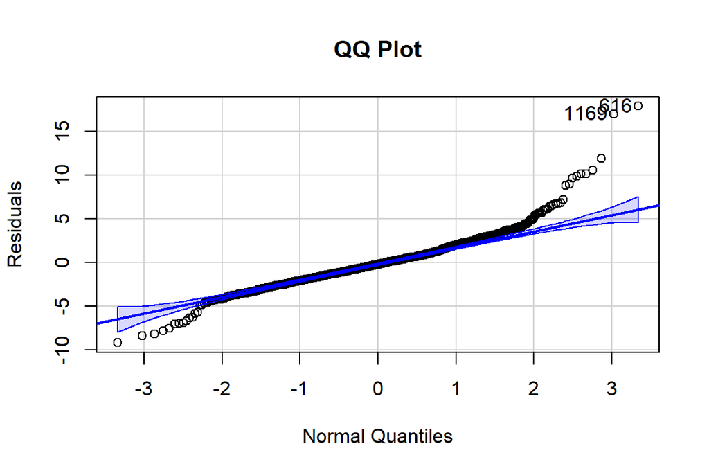

```r
qq_gwr_results_dat <- qqPlot(gwr_results_dat$SDF$residual, main = "QQ Plot", xlab = "Normal Quantiles", ylab = "Residuals")
```

```r
print(qq_gwr_results_dat)
```

```
[1]  616 1169
```

Again, we see that the residuals aren’t normally distributed in the GWR model. There are still some lurking relationships.

##### 2.4.4.1.2 Spatial Autocorrelation of Residuals

Just like we did for the linear model, we’ll test the spatial autocorrelation of model residuals. First, we define the neighborhood kernel function `nb` and weighting scheme `lw`.

```r
# Spatial autocorrelation of basic GWR residuals
nb <- poly2nb(gwr_results_dat$SDF, queen = TRUE) # Define neighbors for each polygon
lw <- nb2listw(nb, style = "U", zero.policy = TRUE) # Assign weights to neighbors
moran_gwr <- moran.mc(gwr_results_dat$SDF$residual
                    , lw
                    , nsim = 999
                    , alternative = "two.sided")
print(rbind("Moran's I statistic: " ,moran_gwr$statistic))
```

```
     statistic
[1,] "Moran's I statistic: "
[2,] "0.0534032559792588"
```

```r
print(rbind("P-value of Moran's I statistic: ", moran_gwr$p.value))
```

```
     [,1]
[1,] "P-value of Moran's I statistic: "
[2,] "0.002"
```

The Moran’s $I$ statistic of the GWR model is 0.0534 and the p-value is 0.002. Because the $p-value$ is $<0.05$, we can conclude at a 95% CI that the residuals are significantly spatially autocorrelated, meaning that there are significant spatial relationships in the data that are not reconciled by the current local model.

#### 2.4.4.2 Plot Distribution of Beta Coefficients

Similar to global linear models, GWR returns $\beta$ coefficients for each explanatory variable. However, there are beta coefficients for each explanatory variable at each observation as defined by the model fit in the local neighborhood. A helpful way to interpret this is to look at the overall distribution of each $\beta$.

We first reshape the coefficient data table using the *melt()* function to reshape the data from wide to long format and define a new variable `melt_coefficients`. We then use *GGplot2* to draw boxplots of the distributions with *geom_boxplot()* and draw a red dashed line at y=0 with *geom_hline* to help with our interpretation. The plot is named `p_gwr_bp`.

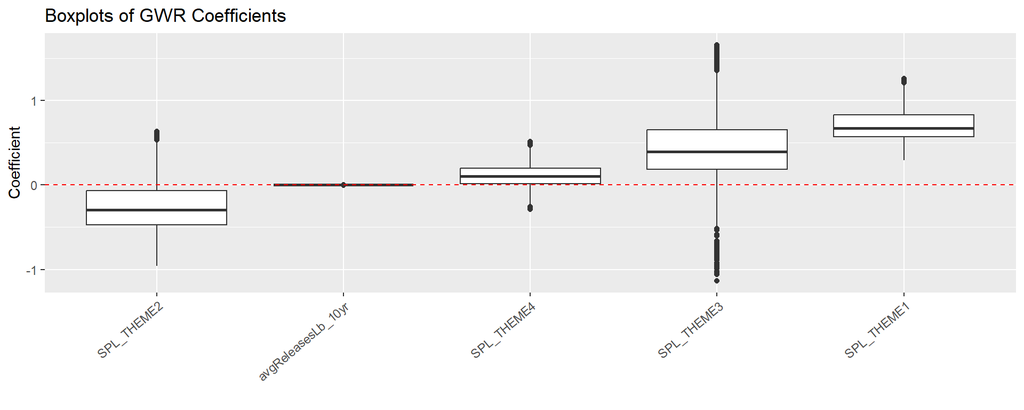

```r
# Boxplots of coefficients
# coefficients <- data.frame(mgwr_results_dat_full$SDF[, 2:11])
coefficients <- data.frame(gwr_results_dat$SDF[, 2:6])
melt_coefficients <- reshape2::melt(coefficients)

p_gwr_bp <- ggplot(melt_coefficients, aes(x = fct_reorder(variable, value, .fun = mean), y = value))
p_gwr_bp <- p_gwr_bp + geom_boxplot()
p_gwr_bp <- p_gwr_bp + labs(x = "", y = "Coefficient") + ggtitle("Boxplots of GWR Coefficients")
p_gwr_bp <- p_gwr_bp + theme(axis.text.x = element_text(angle = 40, hjust = 1))
p_gwr_bp <- p_gwr_bp + geom_hline(yintercept = 0, linetype = "dashed", color = "red")

print(p_gwr_bp)
```

#### 2.4.4.3 Mapping GWR Beta Coefficients

Run the code chunk below to generate maps. The code will generate a map of the census tracts of Colorado colored by the $\beta$ coefficients of each explanatory variable in `gwr_results_dat`. We further shade each census tract where the observation is insignificant at a 95% CI based on the local $T$ value.

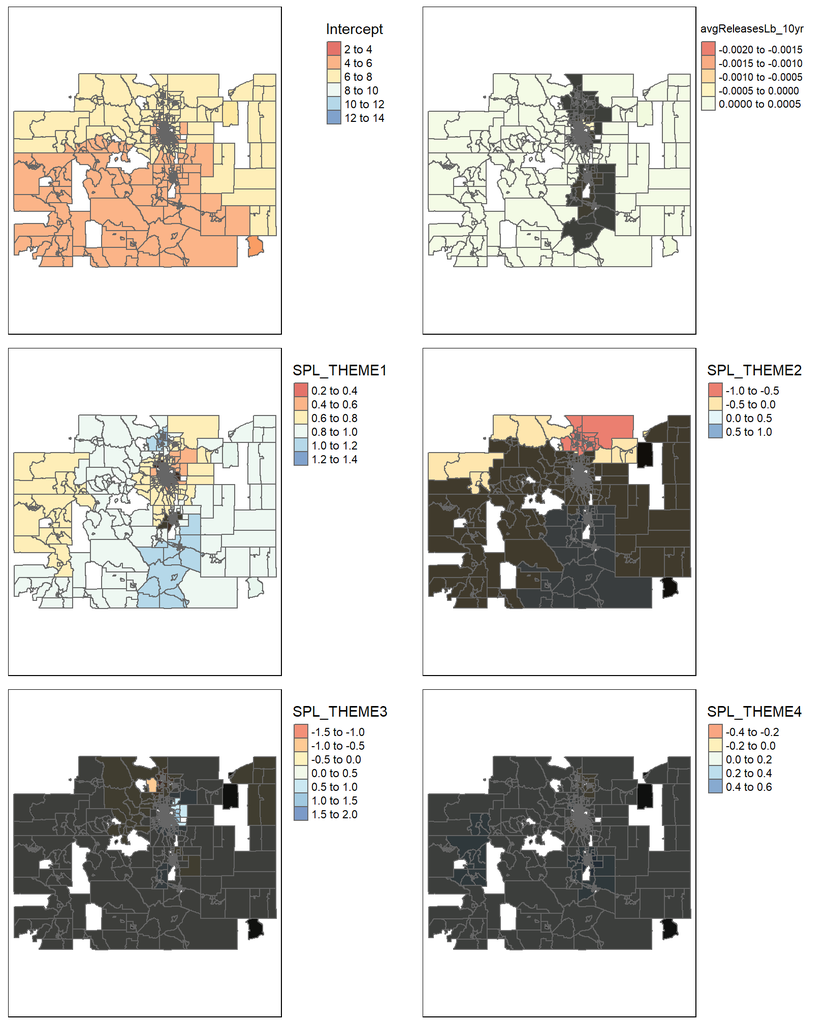

```r
# Map coefficients
p1_gwr <- plot.gwr.coefs(gwr_results_dat$SDF, "Intercept", gwr_results_dat$SDF$Intercept_TV)
p2_gwr <- plot.gwr.coefs(gwr_results_dat$SDF, "avgReleasesLb_10yr", gwr_results_dat$SDF$avgReleasesLb_10yr_TV)
p3_gwr <- plot.gwr.coefs(gwr_results_dat$SDF, "SPL_THEME1", gwr_results_dat$SDF$SPL_THEME1_TV)
p4_gwr <- plot.gwr.coefs(gwr_results_dat$SDF, "SPL_THEME2", gwr_results_dat$SDF$SPL_THEME2_TV)
p5_gwr <- plot.gwr.coefs(gwr_results_dat$SDF, "SPL_THEME3", gwr_results_dat$SDF$SPL_THEME3_TV)
p6_gwr <- plot.gwr.coefs(gwr_results_dat$SDF, "SPL_THEME4", gwr_results_dat$SDF$SPL_THEME4_TV)


p_gwr <- tmap_arrange(p1_gwr
                    , p2_gwr
                    , p3_gwr
                    , p4_gwr
                    , p5_gwr
                    , p6_gwr
                    , ncol = 2)
print(p_gwr)
```

In the maps above, we see that `avgReleasesLb_10yr` is significant (95% CI) and positive (though only slightly) across most of the state, but that it is consistently insignificant throughout the central portion of Colorado where most of the population is concentrated and where census tracts tend to be considerably smaller. What other explanatory variables might help improve these results?

#### 2.4.4.4 Map Local R2

Another important output from GWR models is the local $R^2$ – the $R^2$ value at every observation.

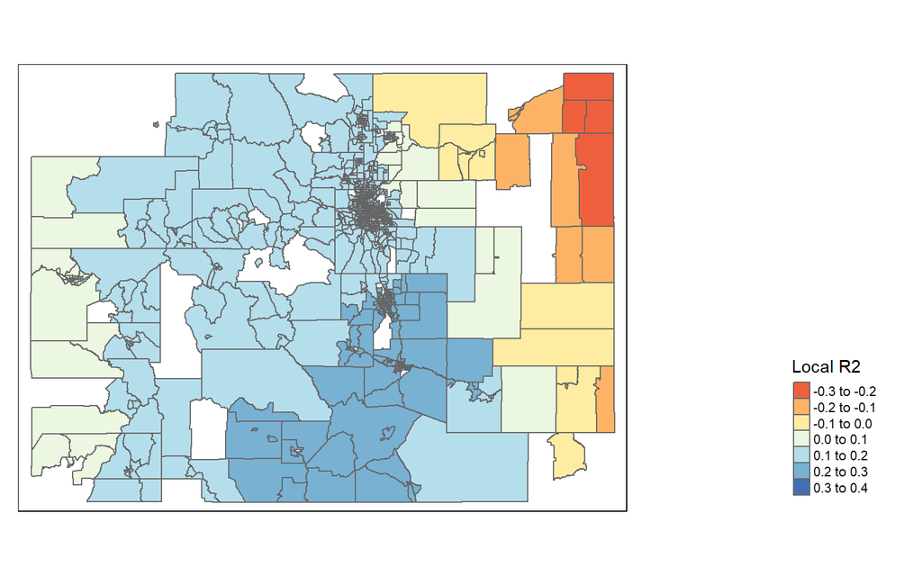

```r
# Plot local R2
p_gwr <- tm_shape(gwr_results_dat$SDF) +
  tm_polygons("Local_R2", palette = "RdYlBu", title = "Local R2") +
  tm_layout(legend.position = c("right", "bottom"),
            legend.outside = TRUE
            )

print(p_gwr)
```

In the map above, we see that the predictive power of the GWR model is spatially heterogeneous, with the strongest predictive power in census tracts throughout the south-central portion of Colorado. Further, we see that the model is poorly specified in most census tracts along the eastern portion of the state. Beyond including spatial relationships as model dependencies, GWR can also help us identify specific locations or regions where our models fail to predict outcomes, possibly narrowing our search for other potential covariates.

# 3 Conclusion

Congratulations! You have made it to the last step of the workshop. So far, you have:

1. Formatted data
2. Ran spatial statistical tests
3. Analyzed model diagnostics, and
4. Plotted a simple map of model results.

The main takeaway from this workshop is that there are sophisticated techniques for exploring the inherently spatial nature of environmental exposures and health outcomes. With some minimal data formatting, you should be able to modify the code contained here to explore these types of relationships in your own research.

This is a crucial takeaway: spatial regression models don’t automatically resolve lurking spatial relationships, but they do account for some portion of them. Aside from identifying more variables to explain the spatial nature of exposure-outcome models, recall that there are other approaches like spatial autoregressive (SAR) models, which introduce spatial lag or spatial error terms to the regression. It’s worth noting that SAR models are inherently global because they cannot spatially locate outliers.

[output not shown]

If you have time, consider running the remaining code to conduct a multiscale GWR. As long as everything before this point has been run, the MGWR will work with all of the data and objects in the current R environment.

## 3.1 Optional Step: MGWR

### 3.1.1 Run MGWR (OPTIONAL STEP 1)

*To see what an optimized model looks like, refer to the HTML document in which the model was run with a maximum of 100 iterations.* If you happen to have a powerful laptop, try running this step again after you complete the workshop with more iterations to see how the model improves. *This will take a at least a couple of hours with the current dataset.*

*Note: even when using 1 iteration, the model can take several minutes to run. Start the code chunk below and sit back. If it takes to long, do not fret! Feel free to follow along with us for the final steps and reference to pdf*

```r
# Multiscale geographically weighted regression
# Documentation: https://search.r-project.org/CRAN/refmans/GWmodel/html/gwr.multiscale.html
mgwr_results_dat_full <- gwr.multiscale(LWB_ADJRATE ~ avgReleasesLb_10yr
                                               + SPL_THEME1
                                               + SPL_THEME2
                                               + SPL_THEME3
                                               + SPL_THEME4
                                      , data = dat_full
                                      , max.iterations = 100 # Set max iterations higher to optimize model - it's at 2 now to minimize computational burden
                                      , kernel = "gaussian" # wgt = exp(-.5*(vdist/bw)^2);
                                      # , kernel = "exponential" # wgt = exp(-vdist/bw);
                                      # , kernel = "bisquare" # wgt = (1-(vdist/bw)^2)^2 if vdist < bw, wgt=0 otherwise;
                                      # , kernel = "tricube" # wgt = (1-(vdist/bw)^3)^3 if vdist < bw, wgt=0 otherwise;
                                      # , kernel = "boxcar" # wgt=1 if dist < bw, wgt=0 otherwise
                                      , adaptive = TRUE
                                      , criterion = "CVR"
)
```

[output not shown]

[output cut: 735 more lines]

```
    Iteration  96 :
    Ieration  95 the change value of RSS (CVR) is:  0.2169199
----------End of    Iteration  96 ----------
    Iteration  97 :
    Ieration  96 the change value of RSS (CVR) is:  0.2123939
----------End of    Iteration  97 ----------
    Iteration  98 :
    Ieration  97 the change value of RSS (CVR) is:  0.2079076
----------End of    Iteration  98 ----------
    Iteration  99 :
    Ieration  98 the change value of RSS (CVR) is:  0.2034645
----------End of    Iteration  99 ----------
    Iteration  100 :
    Ieration  99 the change value of RSS (CVR) is:  0.1990682
----------End of    Iteration  100 ----------
```

```r
# Model outputs
print(mgwr_results_dat_full)
```

```
   *                       Package   GWmodel                             *
   Program starts at: 2024-02-06 15:24:05
   Call:
   gwr.multiscale(formula = LWB_ADJRATE ~ avgReleasesLb_10yr + SPL_THEME1 +
    SPL_THEME2 + SPL_THEME3 + SPL_THEME4, data = dat_full, kernel = "gaussian",
    adaptive = TRUE, criterion = "CVR", max.iterations = 100)

   Dependent (y) variable:  LWB_ADJRATE
   Independent variables:  avgReleasesLb_10yr SPL_THEME1 SPL_THEME2 SPL_THEME3 SPL_THEME4
   Number of data points: 1201
   *                       Multiscale (PSDM) GWR                          *

   *********************Model calibration information*********************
   Kernel function: gaussian
   Adaptive bandwidths for each coefficient(number of nearest neighbours):
              (Intercept) avgReleasesLb_10yr SPL_THEME1 SPL_THEME2 SPL_THEME3
   Bandwidth           13                300        959       1161         62
              SPL_THEME4
   Bandwidth         825

   ****************Summary of GWR coefficient estimates:******************
                             Min.     1st Qu.      Median     3rd Qu.    Max.
   Intercept           4.3547e+00  5.3874e+00  5.7526e+00  6.2112e+00  7.8999
   avgReleasesLb_10yr  7.2813e-06  1.1225e-05  3.2085e-05  5.6220e-05  0.0001
   SPL_THEME1          5.8875e-01  6.1424e-01  6.1846e-01  6.3310e-01  0.6847
   SPL_THEME2         -2.6733e-01 -2.4914e-01 -2.4635e-01 -2.4356e-01 -0.1981
   SPL_THEME3         -5.2966e-01  2.8278e-01  5.2404e-01  1.0687e+00  1.8262
   SPL_THEME4          5.9127e-03  2.7713e-02  3.2527e-02  6.9541e-02  0.1061
   ************************Diagnostic information*************************
   Number of data points: 1201
   Effective number of parameters (2trace(S) - trace(S'S)): 70.85964
   Effective degrees of freedom (n-2trace(S) + trace(S'S)): 1130.14
   AICc value:  5560.032
   AIC value:  5490.648
   BIC value:  4658.804
   Residual sum of squares:  6465.904
   R-square value:  0.2261403
   Adjusted R-square value:  0.1775764

   Program stops at: 2024-02-06 17:20:27
```

### 3.1.2 MGWR Model Interpretation (OPTIONAL STEP 2)

#### 3.1.2.1 Model Diagnostics

```r
# Model diagnostics
print(mgwr_results_dat_full$GW.diagnostic)
```

```
$RSS.gw
[1] 6465.904

$AICc
[1] 5560.032

$AIC
[1] 5490.648

$BIC
[1] 4658.804

$R2.val
[1] 0.2261403

$R2adj
[1] 0.1775764

$edf
[1] 1130.14

$enp
[1] 70.85964
```

##### 3.1.2.1.1 Normality of Residuals

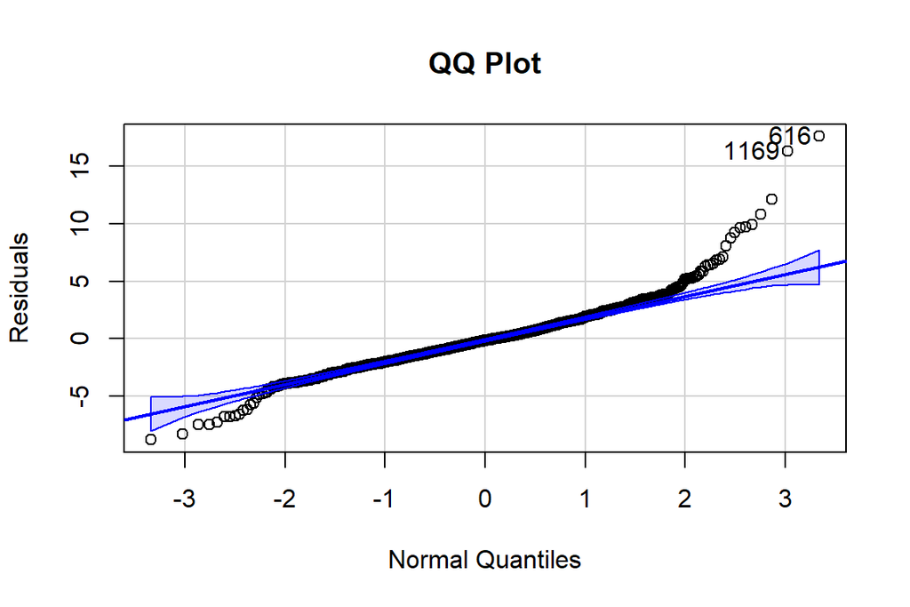

```r
qq_gwr_results_dat <- qqPlot(mgwr_results_dat_full$SDF$residual, main = "QQ Plot", xlab = "Normal Quantiles", ylab = "Residuals")
```

```r
print(qq_gwr_results_dat)
```

```
[1]  616 1169
```

What do you see in the model residuals? What does it mean if they’re not normally distributed?

##### 3.1.2.1.2 Spatial Autocorrelation

```r
# Spatial autocorrelation of MGWR residuals
nb <- poly2nb(mgwr_results_dat_full$SDF, queen = TRUE) # Define neighbors for each polygon
lw <- nb2listw(nb, style = "U", zero.policy = TRUE) # Assign weights to neighbors
moran_mgwr <- moran.mc(mgwr_results_dat_full$SDF$residual
                       , lw
                       , nsim = 999
                       , alternative = "two.sided")
print(rbind("Moran's I statistic: " ,moran_mgwr$statistic))
```

```
     statistic
[1,] "Moran's I statistic: "
[2,] "0.00310181276410573"
```

```r
print(rbind("P-value of Moran's I statistic: ", moran_mgwr$p.value))
```

```
     [,1]
[1,] "P-value of Moran's I statistic: "
[2,] "0.838"
```

The Moran’s $I$ statistic of the multiscale GWR model is 0.0031 and the p-value is 0.838. Because the $p-value$ is $>0.05$, we can conclude at a 95% CI that the residuals are not significantly spatially autocorrelated, meaning that the model is correctly specified in terms of lurking spatial relationships.

#### 3.1.2.2 Plot Distribution of Beta Coefficients

Exactly as with GWR models, MGWR returns $\beta$ coefficients for each explanatory variable. Run the code chunk below to plot boxplots of MGWR coefficients, `p_mgwr_bp`.

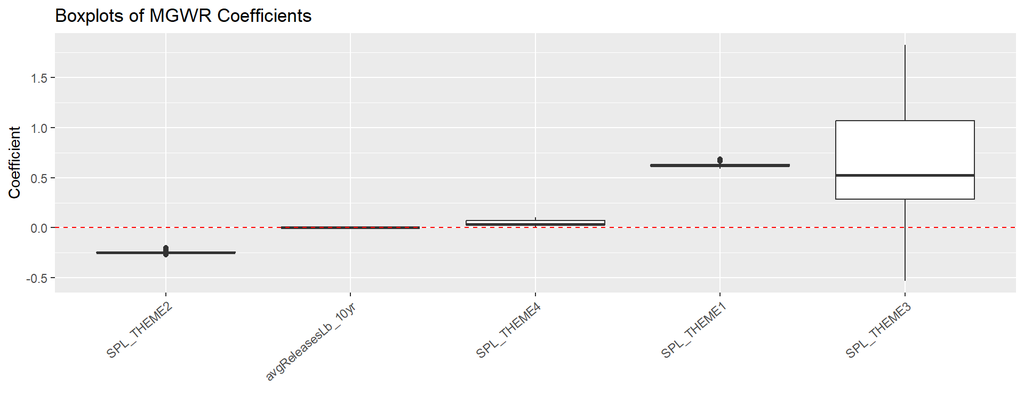

```r
# Boxplots of coefficients
# coefficients <- data.frame(mgwr_results_dat_full$SDF[, 2:11])
coefficients <- data.frame(mgwr_results_dat_full$SDF[, 2:6])
melt_coefficients <- reshape2::melt(coefficients)

p_mgwr_bp <- ggplot(melt_coefficients, aes(x = fct_reorder(variable, value, .fun = mean), y = value))
p_mgwr_bp <- p_mgwr_bp + geom_boxplot()
p_mgwr_bp <- p_mgwr_bp + labs(x = "", y = "Coefficient") + ggtitle("Boxplots of MGWR Coefficients")
p_mgwr_bp <- p_mgwr_bp + theme(axis.text.x = element_text(angle = 40, hjust = 1))
p_mgwr_bp <- p_mgwr_bp + geom_hline(yintercept = 0, linetype = "dashed", color = "red")

print(p_mgwr_bp)
```

$\textbf{A note on MGWR iterations:}$ In the HTML document you will see that we ran the MGWR with a maximum of 100 iterations in hopes that the model will converge using the CVR backfitting criterion. Even though it doesn’t converge with this adjustment, we do see different results for multiple model diagnostics, holding everything else constant. Most notably, $\beta$ coefficients for `SPL_THEME1` are now solidly positive. While you can make meaningful inference about model strength with one or a few iterations, it’s good practice to let the model approach convergence.

## 3.2 Mapping Results (OPTIONAL STEP 3)

Run the code chunk below to generate maps of MGWR $\beta$ coefficients. *Note: depending on your computer, the maps may take a while to generate.*

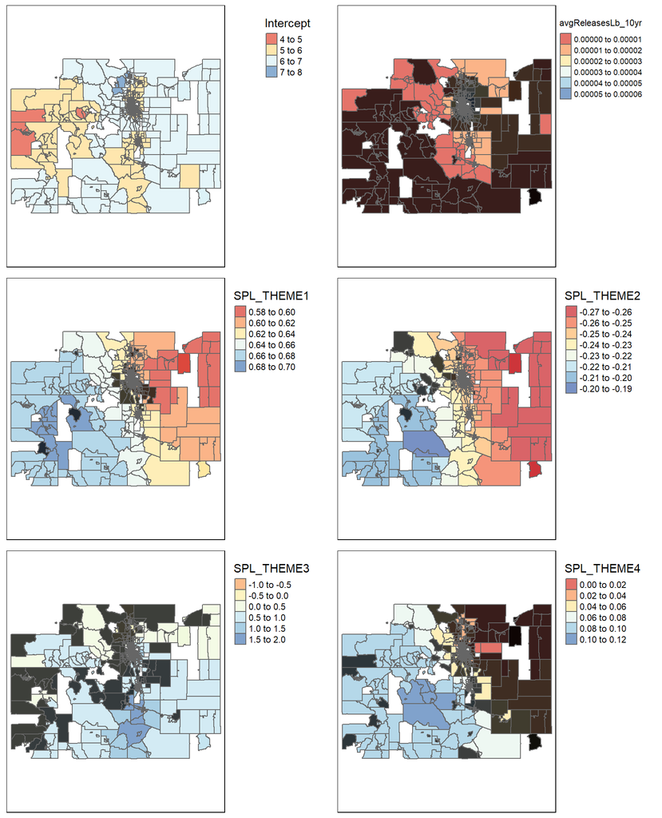

```r
# Map coefficients
p1_mgwr <- plot.gwr.coefs(mgwr_results_dat_full$SDF, "Intercept", mgwr_results_dat_full$SDF$Intercept_TV)
p2_mgwr <- plot.gwr.coefs(mgwr_results_dat_full$SDF, "avgReleasesLb_10yr", mgwr_results_dat_full$SDF$avgReleasesLb_10yr_TV)
p3_mgwr <- plot.gwr.coefs(mgwr_results_dat_full$SDF, "SPL_THEME1", mgwr_results_dat_full$SDF$SPL_THEME1_TV)
p4_mgwr <- plot.gwr.coefs(mgwr_results_dat_full$SDF, "SPL_THEME2", mgwr_results_dat_full$SDF$SPL_THEME2_TV)
p5_mgwr <- plot.gwr.coefs(mgwr_results_dat_full$SDF, "SPL_THEME3", mgwr_results_dat_full$SDF$SPL_THEME3_TV)
p6_mgwr <- plot.gwr.coefs(mgwr_results_dat_full$SDF, "SPL_THEME4", mgwr_results_dat_full$SDF$SPL_THEME4_TV)


p_mgwr <- tmap_arrange(p1_mgwr
                     , p2_mgwr
                     , p3_mgwr
                     , p4_mgwr
                     , p5_mgwr
                     , p6_mgwr
                     , ncol = 2)
print(p_mgwr)
```

In the map above, we see that the main exposure variable, `avgReleasesLb_10yr` is only significant in about half of the census tracts, and that the linear relationship between it and `LWB_ADJRATE` is generally quite small, albeit positive. This suggests that while the model is generally well-specified, future work ought to explore more influential exposure variables on LWB.

Finally, let’s compare selected diagnostics across all three models:

[output not shown]

*This workshop is supported by the UNM Center for Native Environmental Health Equity Research – A Center of Excellence In Environmental Health Disparities Research (P50MD015706). Additional support comes from the University of New Mexico METALS Superfund Research Program (1P42ES025589) and the New Mexico Integrative Science Program Incorporating Research in Environmental Sciences (NM-INSPIRES) Center at the University of New Mexico (1P30ES032755). The material presented here has not been formally reviewed by the funding agencies. The views expressed herein are solely those of the authors and do not necessarily reflect those of the agencies.*